# CPS85 Lab

Sep. 8, 2015

## Instructions

**Important:** Make sure you delete this entire section before you submit your file to RPubs!

In your groups, tackle the `CPS85` dataset within the `mosaicData` package. You may want to type `?CPS85` and `head(CPS85)` to get a glimpse at what this dataset contains. Next, start exploring the dataset using plots, tables, and other numeric summaries. Select 3 favorite plots and tell a story (in writing) about each of them. Extra brownie points if you can weave the 3 plots together into one cohesive story. You should include at least 1 univariate and 1 bivariate plot.

## PLOT 1

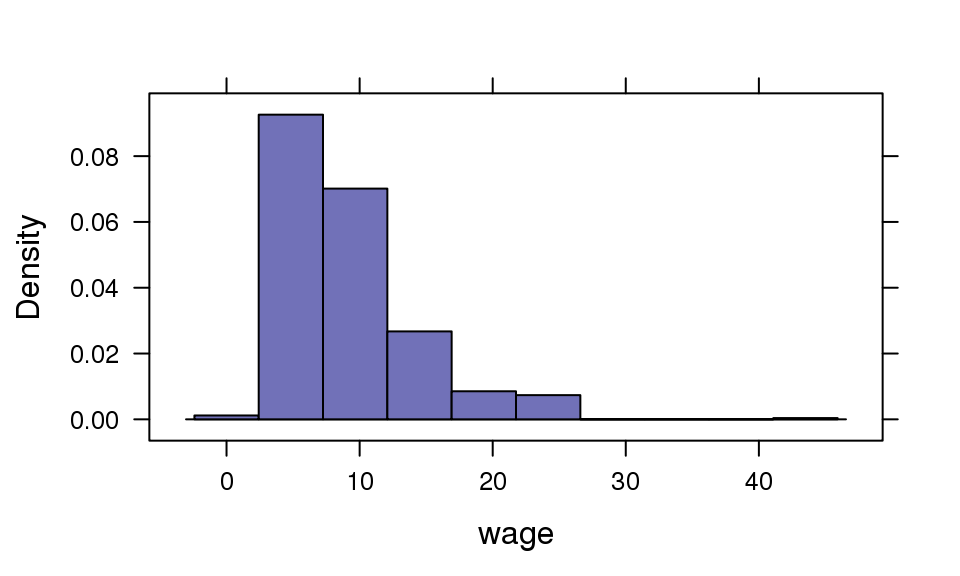

```r
histogram(~wage, data=CPS85)
```

The Histogram depicts the density of each wage level from 0 to 40 within the sample population.

## PLOT 2

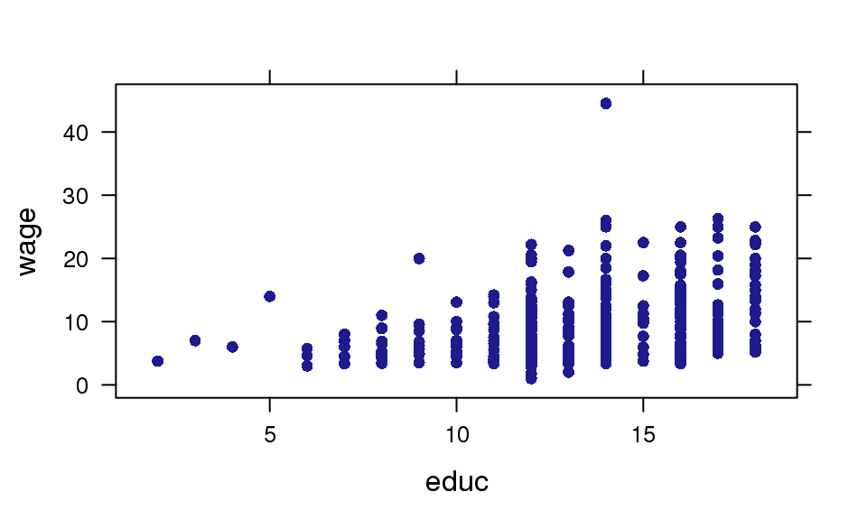

```r
xyplot(wage ~ educ, data=CPS85)
```

## PLOT 3

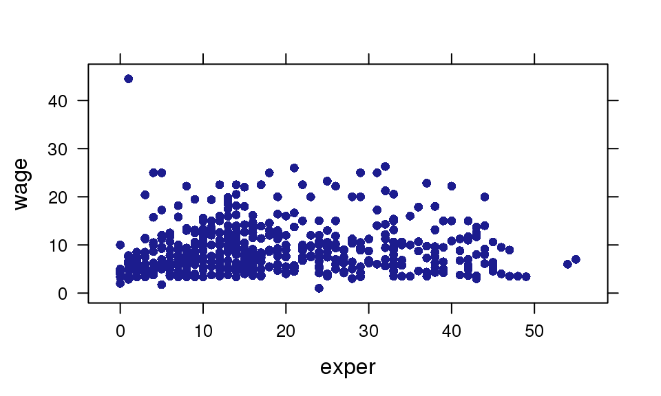

```r
xyplot(wage ~ exper, data=CPS85)
```